# Parliament Member Data

Thorkil

1/3/2018

## Set up necessities

```r
library(httr) #To access and get data from the api
library(dplyr) #To clean up the new data data
library(rebus) #An intuitive guide to regular expressions
library(stringr) #To work with strings in a concise way
library(ggplot2) #For visualization
library(ggthemes) #For filling of plots
```

# 1. The goals of this script

This script downloads data from the Danish Parliament API to produce a dataframe with parliament member data, containing 1) Member name, 2) Member party and 3) Member education

# STEP 1: Getting the membership data

Bjørn has made the skeleton of a wicked function, that gets data from the Folketinget API and puts it in a data frame format. I have fine-tuned this function, by adding two arguments: A filter_equal argument, allowing one to restrict the search to data where a given parameter is equal to a character vector, and a filter_contain argument, allowing one to restrict the search to data where a given parameter contains a character vector. By using this function, I can get a data-set of all parliament member names!

I setup the function, that allows me to get data from the Folketinget API

```r
collect_ft_data <- function(url_basic, parameter_vector, max_obs, filter_equal=NULL, filter_contain=NULL){
  ### The following function collects data from the API of the Danish Parliament
  ### The function needs three inputs and returns a dataframe:
  ###     1) A URL provided by the API (www.http://oda.ft.dk/) with the data of interest (e.g.www.http://oda.ft.dk/api/Afstemning?$inlinecount=allpages).
  ###     2) A character vetor with the names of parameters you are interested in (e.g. c("id", "vedtage", "typeid")). The maximum number of variables is 15.
  ###     3) The number of observations you want to collect. Default is all observations.
  ###     4) A FILTER FOR THE SEARCH, CONTAINS VECTOR WITH c("attribute", "search.term")

  #Making the filter into url, if one of them is specified
  if (length(filter_equal)>1){
    chr.filter <- c("&$filter=", URLencode(filter_equal[1], reserved=T),"%20eq%20",URLencode(filter_equal[2], reserved=T))
  } else if (length(filter_contain)>1){
    chr.filter <- c("&$filter=substringof('", URLencode(filter_contain[2], reserved=T),"',", URLencode(filter_contain[1], reserved=T),")")
  } else {
    chr.filter <- NULL
  }

  #Make the new filter URL
  filter_url <- paste(chr.filter, collapse="")
  #combine with entire URL
  full_url <- paste0(url_basic, filter_url, collapse="")

  # Making a GET-request
  data_page <- GET(full_url)
  data_content <- content(data_page)
  num_obs <- data_content$odata.count
  print(paste0("The dataset has ", num_obs, " observations"))

  # Creating empty dataframe
  df <- data.frame(NA) #Make dataset full of NA
  for (i in parameter_vector){df[,i] <- NA} #Make a collumn for each parameter
  df <- df[-1] #Removes first variable from empty df

  # Setting the number of data observations that the function collects
  if(missing(max_obs)) {
    obs_collect <- num_obs #Default is all observation
  } else {
    obs_collect <- max_obs #Else the specified amount
  }

  # Collecting data with the selected variables and number of observations
  seqnr <- seq(from=0, to=obs_collect, by=20) #How many searches must be made. Each page returns 20 obs

  for(i in seqnr) {
    link <- paste0(full_url,"&$skip=",i) #Skip = antal obs already taken
    data.temp <- GET(link)
    data.temp.content <- content(data.temp)
    values = data.temp.content$value #Take only the values-element of the content-list

    for(j in 1:length(values)) { #For every observation of the current page
      df[i + j,] <- c(values[[j]][[parameter_vector[1]]], #Take this entire vector, with all the parameter values, and store it as the first obs in the data
                      values[[j]][[parameter_vector[2]]],
                      values[[j]][[parameter_vector[3]]],
                      values[[j]][[parameter_vector[4]]],
                      values[[j]][[parameter_vector[5]]],
                      values[[j]][[parameter_vector[6]]],
                      values[[j]][[parameter_vector[7]]],
                      values[[j]][[parameter_vector[8]]],
                      values[[j]][[parameter_vector[9]]],
                      values[[j]][[parameter_vector[10]]],
                      values[[j]][[parameter_vector[11]]],
                      values[[j]][[parameter_vector[12]]],
                      values[[j]][[parameter_vector[13]]],
                      values[[j]][[parameter_vector[14]]],
                      values[[j]][[parameter_vector[15]]])
    }}
  return(df)
}
```

Now, I can use that function to get data on the parliament members

```r
#I make a data frame with data from members (biografri contains the word "medlem" meaning "member")
member_df<-collect_ft_data("http://oda.ft.dk/api/Akt%C3%B8r?$inlinecount=allpages",c("id", "navn", "typeid", "biografi"), filter_contain = c("biografi", "medlem"))

#And a data frame with data from temporary members (biografri contains the word "Midlertidigt Folketingsmedlem", e.g. because the member substitutes a permanent member who is on paternity/maternity leave)
temporary_member_df<-collect_ft_data("http://oda.ft.dk/api/Akt%C3%B8r?$inlinecount=allpages",c("id", "navn", "typeid", "biografi"), filter_contain = c("biografi", "Midlertidigt folketingsmedlem"))

#I realise, that the temporary members have already been added to the member variable by the Danish parliament, so I dont include them

#Make one dataset
all_members_df<- member_df

#Save the raw data
setwd("/Users/thorkilklint/Documents/Berkeley/PS239T_Computational/ps239T-final-project/Data")
write.csv(all_members_df, "all_members_data_raw.csv")
saveRDS(all_members_df,file="all_members_data_raw.Rda")
```

# STEP 2: Cleaning the data

Import the data

```r
setwd("/Users/thorkilklint/Documents/Berkeley/PS239T_Computational/ps239T-final-project/Data")
all_members_df<-readRDS("all_members_data_raw.Rda")
```

##STEP 2.1: Rename the name variable

```r
#I rename the variable from Danish to english
names(all_members_df)[names(all_members_df) == "navn"] <- "name"

#How many duplicated duplicates?
nrow(duplicated(all_members_df))
```

[output not shown]

Now,I have a vector with all parliament member names - both former (in modern era) and current AND a dataset with temporary member data. Based on my debate I notice, that one name “Frank Aaen (udpeget af EL)” has a weird format, why I change it. I also notice, that some names are not similar accross debate resumé and api-data. There is not easy fix, and I will have to detect it, once it occurs. Fow now, I will correct it by hand:

```r
all_members_df$name[all_members_df$name=="Frank Aaen (udpeget af EL)"]<-"Frank Aaen"
all_members_df$name[all_members_df$name=="Simon Emil Ammitzbøll-Bille"]<-"Simon Emil Ammitzbøll"
str(all_members_df)
```

```
## 'data.frame':    292 obs. of  4 variables:
##  $ id      : chr  "5" "12" "13" "17" ...
##  $ name    : chr  "Frank Aaen" "Nicolai Wammen" "Sara Olsvig" "Christine Antorini" ...
##  $ typeid  : chr  "5" "5" "5" "5" ...
##  $ biografi: chr  "<?xml version=\"1.0\" encoding=\"utf-16\"?>\n<membersMember xmlns:xsi=\"http://www.w3.org/2001/XMLSchema-instan"| __truncated__ "<membersMember tid=\"0\"><itemname>SNIWA</itemname><url>http://www.ft.dk/da/medlemmer/folketingetsmedlemmer/nic"| __truncated__ "<?xml version=\"1.0\…
```

## STEP 2.2: Extracting the party of the speaker

I start by making a party variable in the member-data from the biografi-variable, using the fact that all bios contains the relevant party abbreviation in paranthesises.

```r
#I make a vector for every party abbreviation
party <- c("EL", "DF", "S", "LA", "RV", "V", "KF","ALT", "SF", #Danish Parties
           "IA","T", "JF", "UFG", "SIU", "SP") #Greenlandic and Fairy Island Parties

#A search pattern in the members bio's, as all party abbreviations are in (XX)
party_pattern <- OPEN_PAREN %R% or1(party) %R% CLOSE_PAREN

#The I can extract member party
all_members_df$party<-stringr::str_extract(all_members_df$biografi, party_pattern)
```

## STEP 2.3: Extracting the education of the speaker

Through same way I extracted party, I can now extract parliament member education. The latest education the member has achieved occurs first in the biograhy, why I ony have to run a str-extract (which takes occurence of a pattern)

```r
#I extract the education from the membership biographies
all_members_df$education<-str_extract(all_members_df$biografi, "education>.{1,20},") #Take the first up to twenty characters after the "education>" end endning with a ","
all_members_df$education<-str_replace(all_members_df$education, "education>", "") #Remove the "education>"
all_members_df$education<-str_replace(all_members_df$education, "\\<education>", "")#Remove the "<education>"
all_members_df$education<-str_sub(all_members_df$education,1,-2L) #Remove the last comma
```

### Recode education

To use education analytically, I recode the variable to contain information on whether the member has an academic education or not

```r
#144 unique values
unique(all_members_df$education)
```

```
##   [1] "Cand.oecon."          "Cand.scient.pol."     "Antropolog"
##   [4] "Stud.scient.pol."     "Cand.mag. i dansk"    "Studentereksamen"
##   [7] "Hf-student"           "Statskundskab"        "Journalist"
##  [10] NA                     "Læreruddannelsen"     "Aarhus Katedralskole"
##  [13] "Militærtjeneste"      "Buntmagerlærling"     "Cand.pæd. i dansk"
##  [16] "Efg"                  "Officer af reserven"  "Cand.jur."
##  [19] "Ph.d."                "BA i historie"        "Hf-eksamen"
##  [22] "Politibetjent"        "Uddannet lærer"       "Cand.mag.pæd."
##  [25] "Cand.merc.jur."       "Pædagogikum"          "Cand.theol."
##  [28] "Cand.polit."          "Cand.merc."           "Læreruddannet"
##  [31] "Sygeplejerske"        "Folkeskolelærer"      "Ingen uddannelse"
##  [34] "VVS-montør"           "Elektrikeruddannet"   "Lærer"
##  [37] "Politiet"             "BA i statskundskab"   "Automekaniker"
##  [40] "Efterskole"           "Sygehusportør"        "Historiestudier"
##  [43] "Civilingeniør"        "Højskoleophold"       "Cand.scient.soc."
```

[output cut: 33 more lines]

```r
#58 missing. No big worry - the education is not evident from the temporary members biography, why this is not so much of a problem
sum(is.na(all_members_df$education))
```

```
## [1] 58
```

```r
#If you have a university education in Denmark, your title is "cand.xxx.xxx". Further, some other university educations are evident

##Setting up a university pattern
university_pattern<-"Cand|h.d.|Antropolog|Statskundskab|Mag.|Dr.phil|Master"
##Counting the amoung of academics
sum(str_detect(all_members_df$education, pattern=university_pattern), na.rm=T)
```

```
## [1] 87
```

```r
##Making an academic variable
all_members_df$academic<-str_detect(all_members_df$education, pattern=university_pattern)
```

# Quickly visualizing the variables

Education and party

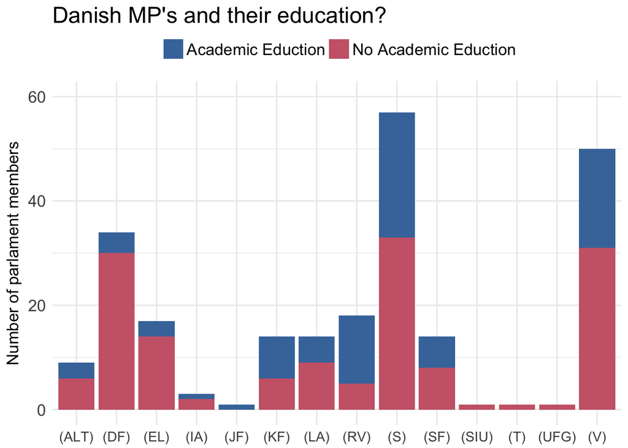

```r
#Set up a fill variable
all_members_df$education_fill<-1:nrow(all_members_df)
all_members_df$education_fill[all_members_df$academic==T]<-"Academic Eduction"
all_members_df$education_fill[all_members_df$academic==F]<-"No Academic Eduction"

#Make the plot
plot1<-ggplot(subset(all_members_df, !is.na(academic) & !is.na(party)), aes(x=party, fill=education_fill))+
  geom_bar()+
  ylab("Number of parlament members") +
  ylim(0,60)+
  theme_minimal() +
  labs(title="Danish MP's and their education?")+
  theme(axis.text.y = element_text(size= 13),
        axis.title.y = element_text(size= 13),
        title=element_text(size=15),
        axis.text.x=element_text(size=11),
        axis.title.x=element_blank(),
        legend.position = "top",
        legend.title=element_blank(),
        legend.text = element_text(size=13))+
  scale_fill_ptol()
plot1
```

```r
#Export the plot
setwd("/Users/thorkilklint/Documents/Berkeley/PS239T_Computational/ps239T-final-project/Results")
ggsave(filename="member_education_and_party.jpg",
       plot=plot1,
       width=18, height=12, units="cm")
```

# Saving membership data

```r
#str(all_members_df)
setwd("/Users/thorkilklint/Documents/Berkeley/PS239T_Computational/ps239T-final-project/Data")
saveRDS(all_members_df,file="all_members_data.Rda") #Save as R data
write.csv(all_members_df, "all_members_data.csv")#Save as csv
```